# Notebook

List available FACTS Data::  
:: FACTS 1.0 run

```
 Index                                                    File Name
     0     coupling.ssp585.ar5AIS.ipccar5.icesheets_AIS_globalsl.nc
     1    coupling.ssp585.ar5AIS.ipccar5.icesheets_EAIS_globalsl.nc
     2    coupling.ssp585.ar5AIS.ipccar5.icesheets_WAIS_globalsl.nc
     3  coupling.ssp585.bamber19.bamber19.icesheets_AIS_globalsl.nc
     4 coupling.ssp585.bamber19.bamber19.icesheets_EAIS_globalsl.nc
     5 coupling.ssp585.bamber19.bamber19.icesheets_WAIS_globalsl.nc
     6      coupling.ssp585.deconto21.deconto21.AIS_AIS_globalsl.nc
     7     coupling.ssp585.deconto21.deconto21.AIS_EAIS_globalsl.nc
     8     coupling.ssp585.deconto21.deconto21.AIS_WAIS_globalsl.nc
     9       coupling.ssp585.emuAIS.emulandice.AIS_EAIS_globalsl.nc
    10        coupling.ssp585.emuAIS.emulandice.AIS_PEN_globalsl.nc
    11       coupling.ssp585.emuAIS.emulandice.AIS_WAIS_globalsl.nc
    12            coupling.ssp585.emuAIS.emulandice.AIS_globalsl.nc
    13           coupling.ssp585.larmip.larmip.AIS_EAIS_globalsl.nc
    14            coupling.ssp585.larmip.larmip.AIS_PEN_globalsl.nc
    15            coupling.ssp585.larmip.larmip.AIS_SMB_globalsl.nc
    16           coupling.ssp585.larmip.larmip.AIS_WAIS_globalsl.nc
    17                coupling.ssp585.larmip.larmip.AIS_globalsl.nc
```

➡ Choose AIS data file.

Select Plot data.  
:: Extract all samples from a particulay year

sklearn KDE  
Visualize the data like in **Gilford20** Figure_4b

Approach —

1. Use [sklearn.neighbors.KernelDensity](https://scikit-learn.org/stable/modules/generated/sklearn.neighbors.KernelDensity.html) to fit a 2-d kernel density estimate to the pairs of, for example, (2030, 2100) in a `2D matrix`.
2. Create a grid of test points. Based on the `max/min` of each column, create a meshgrid `grid_samples`.
3. Use the `score_samples` method of the kernel density estimate to determine a weight for each test point.  
   `log_density_values = kde.score_samples(grid_samples)`
4. Convert it to density `expo(log_density_values)`
5. Normalize the weights column wise. *Divide individual column value by column sum.*
6. Convert back to log values.
7. Do a filled contour plot as in Gilford20.

:: visualize :: Larmip

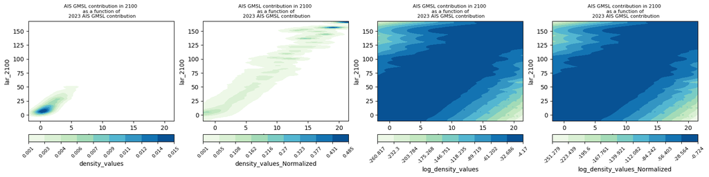

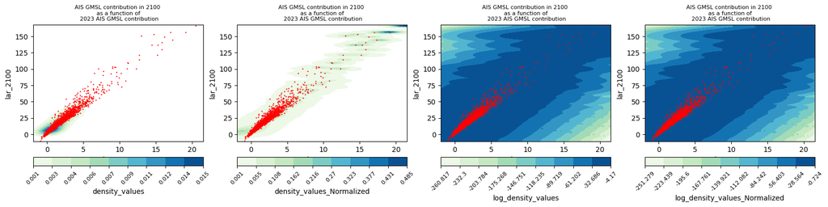

:: visualize :: ar5

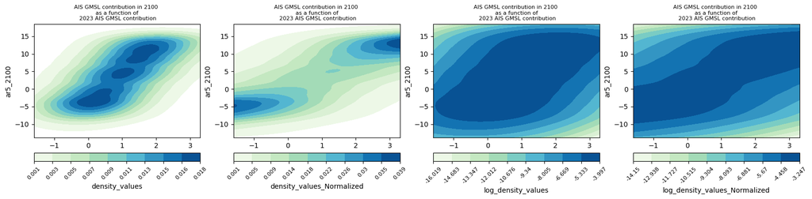

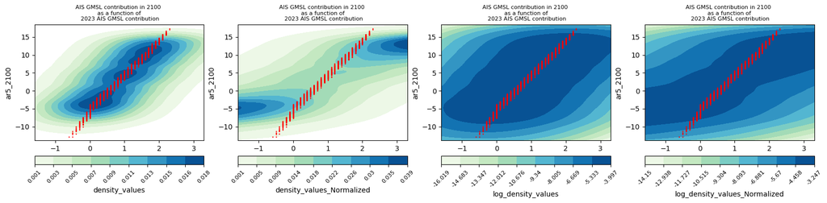

:: visualize :: d21

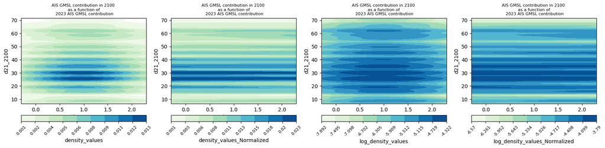

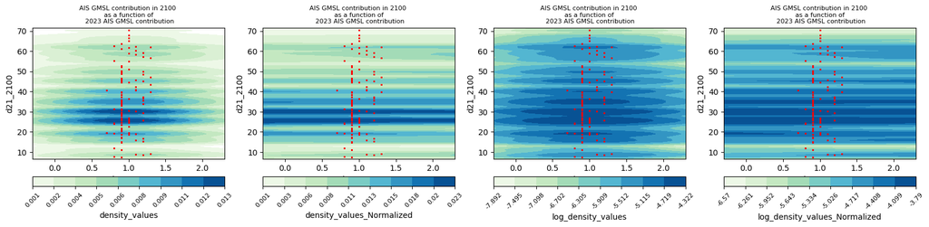

:: visualize :: b19

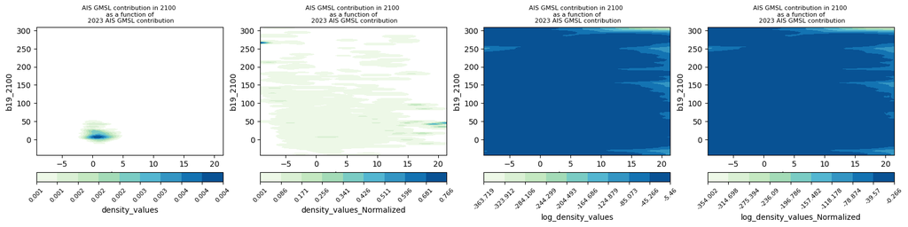

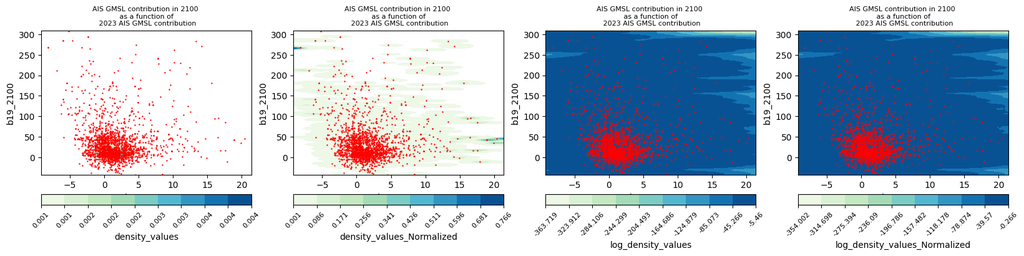

Links —

[sklearn.neighbors.KernelDensity](https://scikit-learn.org/stable/modules/generated/sklearn.neighbors.KernelDensity.html\)  
[kernel-density-estimation](https://scikit-learn.org/stable/modules/density.html#kernel-density-estimation\)